# GBRS Genotype to Neogen Comparison

DMG

8/29/2022

## Introduction

This analysis related to the Arsenic Exposure study in which mice and cell lines are exposed to arsenic and various relevant phenotypes were measured.

GBRS outputs genoprobs on a 69,000 marker grid. It also provides two-letter genotype calls at each gene in the expected counts files. Earlier, I verified that the GBRS genoprobs largely match the Neogen genoprobs, indicating that there were not large-scale sample mixups.

I now want to compare the genotypes in the expected counts file with the maximum marginal genotype call from the Neogen data. This will only be for the subset of ~165 samples which overlap between the two data sets. I previously gathered the genotypes from the individual expected counts files and combined them in one, large matrix.

## Load Data

```r
giga_probs = readRDS(giga_probs_file)
gbrs_probs = readRDS(gbrs_probs_file)
gbrs_geno  = readRDS(gbrs_geno_file)

# Read in sample metadata.
giga_meta = read_xlsx(giga_meta_file)
gbrs_meta = read.csv(gbrs_meta_file, header = FALSE)
colnames(gbrs_meta) = c('dose', 'sex', 'animal', 'fastq1', 'tissue', 'gen', 'fastq2')
gbrs_meta$sample = gsub('_GT22-[0-9]+_[ACGT]+-[ACGT]+_S[0-9]+_L[0-9]+_R1_[0-9]+\\.fastq\\.gz$', '', gbrs_meta$fastq1)

# Read in GBRS markers.
giga_markers = read_csv(giga_marker_file)[,1:5]
giga_markers = subset(giga_markers, !is.na(chr) & ! is.na(bp_mm10))
giga_markers$chr[giga_markers$chr == 'M'] = 'MT'
giga_markers = GRanges(seqnames = giga_markers$chr,
                       ranges   = IRanges(start = giga_markers$bp_mm10, width = 1),
                       marker   = giga_markers$marker)
gbrs_markers = read_delim(gbrs_marker_file)
# Get Ensembl genes.
genes = genes(ensembl)
genes = keepStandardChromosomes(genes, pruning.mode = 'coarse')
genes = subset(genes, seqnames %in% c(1:19, 'X'))

# Get gene midpoints.
genes_mid = GRanges(seqnames = seqnames(genes),
                   ranges   = IRanges(start = 0.5 * (end(genes) + start(genes)), width = 1),
                   gene_id  = genes$gene_id)
```

Both the probs object and the GBRS genotypes have DNA or RNA sample IDs. Change these to mouse IDs and subset the data to contain the same samples in the same order.

```r
new_probs_names = gsub('^Jackson_Lab_(Korstanje|Reinholdt)_MURGIGV01_[0-9]+_|_[A-H][0-9]+$', '',
                       rownames(giga_probs[[1]]))

for(i in seq_along(giga_probs)) {
  rownames(giga_probs[[i]]) = new_probs_names
  giga_probs[[i]]           = giga_probs[[i]][rownames(giga_probs[[i]]) %in% giga_meta$`Extracted DNA`,,]
  rownames(giga_probs[[i]]) = giga_meta$Animal[match(rownames(giga_probs[[i]]), giga_meta$`Extracted DNA`)]
} # for(i)

colnames(gbrs_geno) = gsub('_GT22-[0-9]+_[ACGT]+-[ACGT]+_S[0-9]+$', '', colnames(gbrs_geno))
colnames(gbrs_geno) = gbrs_meta$animal[match(colnames(gbrs_geno), gbrs_meta$sample)]

rownames(gbrs_probs) = gsub('_GT22-[0-9]+_[ACGT]+-[ACGT]+_S[0-9]+$', '', rownames(gbrs_probs))
rownames(gbrs_probs) = gbrs_meta$animal[match(rownames(gbrs_probs), gbrs_meta$sample)]
gbrs_probs           = gbrs_probs[!duplicated(rownames(gbrs_probs)),,]
```

Subset the genes from Ensembl and in GBRS genotypes to contain the same genes.

```r
common_genes = intersect(genes_mid$gene_id, rownames(gbrs_geno))
genes_mid    = subset(genes_mid, gene_id %in% common_genes)
gbrs_geno    = gbrs_geno[genes_mid$gene_id,]

stopifnot(rownames(gbrs_geno) == genes_mid$gene_id)
```

Subset markers in Gigamuga probs to match those in `giga_markers`.

```r
common_markers = intersect(giga_markers$marker, unlist(sapply(giga_probs, function(z) { dimnames(z)[[3]] })))
giga_markers   = subset(giga_markers, marker %in% common_markers)

for(i in seq_along(giga_probs)) {

  giga_probs[[i]] = giga_probs[[i]][,,dimnames(giga_probs[[i]])[[3]] %in% common_markers]

} # for(i)

stopifnot(length(giga_markers) == rowSums(sapply(giga_probs, dim))[3])
```

Get the two-letter genotype calls from the Gigamuga probs.

```r
# This is slow, but seems correct.
get_geno = function(g) {

  # Heterozygote / homozygote cutoff.
  cutoff = 0.75

  # Get maximum probs for each sample/marker.
  maxg   = apply(g, c(1, 3), max)
  whmaxg = apply(g, c(1, 3), which.max)

  # Create new genotype matrix.
  gt = matrix('', nrow = nrow(g), ncol = dim(g)[3],
              dimnames = list(rownames(g), dimnames(g)[[3]]))

  # Handle homozygotes first.
  homo     = which(maxg > cutoff)
  let      = colnames(g)[whmaxg[homo]]
  gt[homo] = paste0(let, let)

  # Handle hets.
  for(i in 1:nrow(g)) {

    # Get the sort order for the probs at this marker.
    g_order = apply(g[i,,], 2, order, decreasing = TRUE)

    # Get het samples.
    het = which(maxg[i,] <= cutoff)
    # Use the sort order from above to the the two highest probs from each
    # het sample.
    let = matrix(colnames(g)[g_order[1:2, het]], ncol = 2, byrow = TRUE)
    # Sort founder alleles to be in alphabetical order.
    let = apply(let, 1, sort)
    # Insert het calls.
    gt[i,het] = paste0(let[1,], let[2,])

  } # for(i)

  return(t(gt))

} # get_geno()

fn = file.path(results_dir, 'giga_geno.rds')
if(!file.exists(fn)) {
  giga_geno = sapply(giga_probs, get_geno)
  giga_geno = do.call(rbind, giga_geno)
  saveRDS(giga_geno, file = fn)
} else {
  giga_geno = readRDS(file = fn)
} # else
```

Are all of the GBRS samples in the Gigamuga dataset?

```r
mean(colnames(gbrs_geno) %in% colnames(giga_geno))
```

```
## [1] 0.9065934
```

Only 90% of the GBRS samples are in the Gigamuga data set. I still want to compare them with the Gigamuga data since one of those samples may have been mismatched. I want to not which samples do not appear in both data sets.

```r
samples_not_in_both = sort(colnames(gbrs_geno)[!colnames(gbrs_geno) %in% colnames(giga_geno)])

samples_not_in_both
```

```
##  [1] "A-10132-19" "A-10133-19" "A-10134-19" "A-10162-19" "A-10257-19"
##  [6] "A-10258-19" "A-10259-19" "A-10261-19" "A-10263-19" "A-10264-19"
## [11] "A-10286-19" "A-10287-19" "A-10290-19" "A-10292-19" "A-10487-19"
## [16] "A-10493-19" "A-10494-19"
```

# Compare Gigmuga Genotypes to GBRS Gene Position Genotypes

Find the marker closest to each gene.

```r
nearest_mkr = nearest(genes_mid, giga_markers)
```

At each gene, verify that we have the correct two-letter genotype calls at each gene.

```r
stopifnot(giga_markers$marker == rownames(giga_geno))
stopifnot(rownames(gbrs_geno) == genes_mid$gene_id)

# Reorder the Gigamuga genotypes to align the closest marker with each gene.
# This may lead to a genotype row being repeated when more than one gene
# is near a marker.
giga_geno_genes = giga_geno[nearest_mkr,]

geno_comp = matrix(0, nrow = ncol(gbrs_geno), ncol = ncol(giga_geno_genes),
                   dimnames = list(colnames(gbrs_geno), colnames(giga_geno_genes)))
for(i in 1:ncol(gbrs_geno)) {

  geno_comp[i,] = colMeans(gbrs_geno[,i] == giga_geno_genes)

} # for(i)
```

Get the Gigamuga sample ID that most closely matches each GBRS sample.

```r
gbrs_giga_comp = data.frame(gbrs_sample = rownames(geno_comp),
                            giga_sample = colnames(geno_comp)[apply(geno_comp, 1, which.max)],
                            sim         = apply(geno_comp, 1, max),
                            self_sim    = geno_comp[cbind(1:nrow(geno_comp), match(rownames(geno_comp), colnames(geno_comp)))])
gbrs_giga_comp$match = gbrs_giga_comp$gbrs_sample == gbrs_giga_comp$giga_sample
gbrs_giga_comp = gbrs_giga_comp[order(gbrs_giga_comp$match),]

gbrs_giga_comp
```

```
##             gbrs_sample giga_sample        sim   self_sim match
## A-10487-19   A-10487-19  A-10490-19 0.76143935         NA FALSE
## A-10491-19   A-10491-19  A-10492-19 0.74010502 0.05751666 FALSE
## A-10492-19   A-10492-19  A-10512-19 0.21866037 0.04955213 FALSE
## A-10493-19   A-10493-19  A-10684-19 0.35771963         NA FALSE
## A-10494-19   A-10494-19  A-10517-19 0.26485902         NA FALSE
## A-10290-19   A-10290-19  A-10308-19 0.24557649         NA FALSE
## A-10292-19   A-10292-19  A-10363-19 0.12860169         NA FALSE
## A-10162-19   A-10162-19  A-10142-19 0.29261351         NA FALSE
## A-10132-19   A-10132-19  A-10137-19 0.30523320         NA FALSE
## A-10133-19   A-10133-19  A-10165-19 0.26602833         NA FALSE
## A-10134-19   A-10134-19  A-10143-19 0.15708423         NA FALSE
## A-10257-19   A-10257-19  A-10106-19 0.10929709         NA FALSE
## A-10258-19   A-10258-19  A-10388-19 0.13736046         NA FALSE
## A-10259-19   A-10259-19  A-10398-19 0.32775890         NA FALSE
## A-10261-19   A-10261-19  A-10630-19 0.10552442         NA FALSE
## A-10263-19   A-10263-19  A-10657-19 0.14078013         NA FALSE
## A-10264-19   A-10264-19  A-10531-19 0.12767507         NA FALSE
## A-10286-19   A-10286-19  A-10103-19 0.08326347         NA FALSE
## A-10287-19   A-10287-19  A-10242-19 0.31941932         NA FALSE
## A-10354-19   A-10354-19  A-10322-19 0.32352292 0.02943123 FALSE
## A-10355-19   A-10355-19  A-10303-19 0.28767154 0.03124035 FALSE
## A-10356-19   A-10356-19  A-10308-19 0.22973569 0.16566650 FALSE
## A-10376-19   A-10376-19  A-10421-19 0.31919869 0.02691612 FALSE
## A-10378-19   A-10378-19  A-10415-19 0.33497330 0.32550854 FALSE
## A-10451-19   A-10451-19  A-10451-19 0.68627278 0.68627278  TRUE
## A-10452-19   A-10452-19  A-10452-19 0.72064599 0.72064599  TRUE
## A-10454-19   A-10454-19  A-10454-19 0.74520143 0.74520143  TRUE
## A-10432-19   A-10432-19  A-10432-19 0.77103649 0.77103649  TRUE
## A-10433-19   A-10433-19  A-10433-19 0.77341923 0.77341923  TRUE
## A-10434-19   A-10434-19  A-10434-19 0.75940961 0.75940961  TRUE
## A-10435-19   A-10435-19  A-10435-19 0.76393240 0.76393240  TRUE
## A-10436-19   A-10436-19  A-10436-19 0.73657503 0.73657503  TRUE
## A-10437-19   A-10437-19  A-10437-19 0.73556016 0.73556016  TRUE
## A-10438-19   A-10438-19  A-10438-19 0.75237171 0.75237171  TRUE
## A-10439-19   A-10439-19  A-10439-19 0.73388342 0.73388342  TRUE
## A-10440-19   A-10440-19  A-10440-19 0.74765036 0.74765036  TRUE
## A-10442-19   A-10442-19  A-10442-19 0.73308918 0.73308918  TRUE
## A-10443-19   A-10443-19  A-10443-19 0.75422495 0.75422495  TRUE
## A-10444-19   A-10444-19  A-10444-19 0.77465472 0.77465472  TRUE
```

[output cut: 128 more lines]

```
## A-10363-19   A-10363-19  A-10363-19 0.77397079 0.77397079  TRUE
## A-10364-19   A-10364-19  A-10364-19 0.76282928 0.76282928  TRUE
## A-10365-19   A-10365-19  A-10365-19 0.73840621 0.73840621  TRUE
## A-10369-19   A-10369-19  A-10369-19 0.74361294 0.74361294  TRUE
## A-10370-19   A-10370-19  A-10370-19 0.73163306 0.73163306  TRUE
## A-10371-19   A-10371-19  A-10371-19 0.73699422 0.73699422  TRUE
## A-10372-19   A-10372-19  A-10372-19 0.73295680 0.73295680  TRUE
## A-10374-19   A-10374-19  A-10374-19 0.76346909 0.76346909  TRUE
## A-10375-19   A-10375-19  A-10375-19 0.73981821 0.73981821  TRUE
## A-10377-19   A-10377-19  A-10377-19 0.72485990 0.72485990  TRUE
## A-10380-19   A-10380-19  A-10380-19 0.73370692 0.73370692  TRUE
## A-10381-19   A-10381-19  A-10381-19 0.76024798 0.76024798  TRUE
## A-10382-19   A-10382-19  A-10382-19 0.75954198 0.75954198  TRUE
## A-10383-19   A-10383-19  A-10383-19 0.74650311 0.74650311  TRUE
## A-10366-19   A-10366-19  A-10366-19 0.75146715 0.75146715  TRUE
```

What is the distribution of the similarity scores?

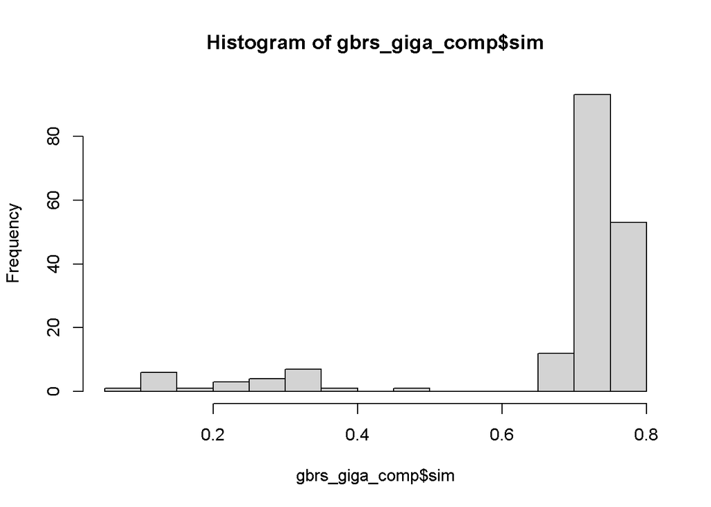

```r
hist(gbrs_giga_comp$sim, breaks = 20)
```

Scores above 0.7 seem to indicate a good match.

What is the mean and standard deviation of the samples that match?

```r
mean(gbrs_giga_comp$sim[gbrs_giga_comp$match == TRUE])
```

```
## [1] 0.7343449
```

```r
sd(gbrs_giga_comp$sim[gbrs_giga_comp$match   == TRUE])
```

```
## [1] 0.04576745
```

Which samples may be mismatched?

```r
gbrs_giga_comp[gbrs_giga_comp$match == FALSE & !is.na(gbrs_giga_comp$self_sim),]
```

```
##            gbrs_sample giga_sample       sim   self_sim match
## A-10491-19  A-10491-19  A-10492-19 0.7401050 0.05751666 FALSE
## A-10492-19  A-10492-19  A-10512-19 0.2186604 0.04955213 FALSE
## A-10354-19  A-10354-19  A-10322-19 0.3235229 0.02943123 FALSE
## A-10355-19  A-10355-19  A-10303-19 0.2876715 0.03124035 FALSE
## A-10356-19  A-10356-19  A-10308-19 0.2297357 0.16566650 FALSE
## A-10376-19  A-10376-19  A-10421-19 0.3191987 0.02691612 FALSE
## A-10378-19  A-10378-19  A-10415-19 0.3349733 0.32550854 FALSE
```

```r
write.csv(gbrs_giga_comp, file = file.path(results_dir, 'gbrs_giga_genotype_mismatch.csv'),
          quote = FALSE, row.names = FALSE)
```

## Compare Gigamuga Genotypes to GBRS Genoprobs Genotypes

Above, we took the two-letter diplotype assigned to each gene by EMASE and compared it to the Gigagmuga maximum marginal diplotype. Here, I will compare the GBRS maximum marginal diplotype to the Gigamuga maximum marginal diplotype. This may seem redundant, but I want to make sure that the genoprobs and genotypes are the same in GBRS.

```r
stopifnot(gbrs_markers$marker == dimnames(gbrs_probs)[[3]])

rm(gbrs_geno, giga_geno_genes, geno_comp)
```

Inerpolate the Gigamuga genoprobs to the 69K grid.

```r
gbrs_markers = GRanges(seqnames = gbrs_markers$chr, ranges = IRanges(start = gbrs_markers$bp, width = 1),
                       marker = gbrs_markers$marker)
names(gbrs_markers) = gbrs_markers$marker

tmp_mkr    = data.frame(marker = gbrs_markers$marker, chr = seqnames(gbrs_markers), pos = start(gbrs_markers))
gbrs_probs = qtl2convert::probs_doqtl_to_qtl2(probs = gbrs_probs, map = tmp_mkr, pos_column = 'pos')
markers2   = qtl2convert::map_df_to_list(tmp_mkr, pos_column = 'pos')
tmp_mkr    = data.frame(marker = giga_markers$marker, chr = seqnames(giga_markers), pos = start(giga_markers))
markers1   = qtl2convert::map_df_to_list(tmp_mkr, pos_column = 'pos')
```

```r
giga_probs_69 = interpolate_genoprobs(giga_probs, markers1, markers2)
```

Make sure that the GBRS and Gigamuga probs are on the same grid.

```r
stopifnot(sapply(gbrs_probs, dim)[3,] == sapply(giga_probs_69, dim)[3,])
```

Compare each GBRS sample with each Gigamuga sample and record the simmilarity

```r
rm(giga_probs)
gc()
```

```
##             used   (Mb) gc trigger    (Mb)   max used    (Mb)
## Ncells   9497464  507.3   17182748   917.7   13545447   723.5
## Vcells 475097991 3624.8 1389342808 10599.9 1388581738 10594.1
```

```r
# Convert the probs back to DOQTL format.
gbrs_probs    = qtl2convert::probs_qtl2_to_doqtl(gbrs_probs)
giga_probs_69 = qtl2convert::probs_qtl2_to_doqtl(giga_probs_69)
```

```r
# Convert the 3D arrays to 2D matrices with samples in columns.
g1 = matrix(0, nrow = ncol(gbrs_probs)    * dim(gbrs_probs)[3],    ncol = nrow(gbrs_probs),
            dimnames = list(NULL, rownames(gbrs_probs)))
g2 = matrix(0, nrow = ncol(giga_probs_69) * dim(giga_probs_69)[3], ncol = nrow(giga_probs_69),
            dimnames = list(NULL, rownames(giga_probs_69)))

for(i in 1:nrow(gbrs_probs)) {

  g1[,i] = gbrs_probs[i,,]

} # for(i)
gbrs_probs = g1
rm(g1)

for(i in 1:nrow(giga_probs_69)) {

  g2[,i] = giga_probs_69[i,,]

} # for(i)
giga_probs_69 = g2
rm(g2)

# Get the similarity between samples.
# I was using Pearson correlation, but then I plotted one sample versus
# itself in the two dataset. Much of the piles up at specific points and I
# wasn't sure how to interpret that.
# So I'm multiplying the genoprobs by 2 and rounding. Then I get the proportion
# of matching rounded genoprobs.
gbrs_rnd = round(2 * gbrs_probs)
giga_rnd = round(2 * giga_probs_69)

sample_sim = matrix(0, nrow = ncol(gbrs_rnd), ncol = ncol(giga_rnd),
                    dimnames = list(colnames(gbrs_rnd), colnames(giga_rnd)))
for(i in 1:ncol(gbrs_rnd)) {
  sample_sim[i,] = colMeans(gbrs_rnd[,i] == giga_rnd)
} # for(i)
```

Which Gigamuga samples correlate best with the GBRS samples?

```r
sample_comp = data.frame(gbrs_mouse = rownames(sample_sim),
                         giga_mouse = colnames(sample_sim)[apply(sample_sim, 1, which.max)],
                         sim        = apply(sample_sim, 1, max),
                         self_sim   = sample_sim[cbind(1:nrow(sample_sim), match(rownames(sample_sim), colnames(sample_sim)))])
sample_comp$match = sample_comp$gbrs_mouse == sample_comp$giga_mouse
sample_comp = sample_comp[order(sample_comp$match, decreasing = FALSE),]

sample_comp
```

```
##              gbrs_mouse  giga_mouse       sim  self_sim match
## A-10133-19   A-10133-19  A-10165-19 0.7701344        NA FALSE
## A-10134-19   A-10134-19  A-10143-19 0.7182414        NA FALSE
## A-10162-19   A-10162-19  A-10142-19 0.7714061        NA FALSE
## A-10263-19   A-10263-19  A-10657-19 0.7228824        NA FALSE
## A-10286-19   A-10286-19  A-10200-19 0.6809416        NA FALSE
## A-10494-19   A-10494-19  A-10517-19 0.7680349        NA FALSE
## A-10354-19   A-10354-19  A-10322-19 0.7950348 0.6581679 FALSE
## A-10259-19   A-10259-19  A-10398-19 0.7856568        NA FALSE
## A-10487-19   A-10487-19  A-10490-19 0.9208409        NA FALSE
## A-10491-19   A-10491-19  A-10492-19 0.9200022 0.6603453 FALSE
## A-10492-19   A-10492-19  A-10512-19 0.7631965 0.6495073 FALSE
## A-10132-19   A-10132-19  A-10137-19 0.7912162        NA FALSE
## A-10287-19   A-10287-19  A-10242-19 0.7855101        NA FALSE
## A-10264-19   A-10264-19  A-10663-19 0.7258115        NA FALSE
## A-10292-19   A-10292-19  A-10363-19 0.7161528        NA FALSE
## A-10258-19   A-10258-19  A-10388-19 0.7177650        NA FALSE
## A-10493-19   A-10493-19  A-10684-19 0.8017064        NA FALSE
## A-10376-19   A-10376-19  A-10444-19 0.8080538 0.6638758 FALSE
## A-10356-19   A-10356-19  A-10308-19 0.7693736 0.7510688 FALSE
## A-10257-19   A-10257-19  A-10106-19 0.7102003        NA FALSE
## A-10290-19   A-10290-19  A-10308-19 0.7741106        NA FALSE
## A-10261-19   A-10261-19  A-10630-19 0.7230038        NA FALSE
## A-10355-19   A-10355-19  A-10303-19 0.7944026 0.6517481 FALSE
## A-100023-20 A-100023-20 A-100023-20 0.9220763 0.9220763  TRUE
## A-100024-20 A-100024-20 A-100024-20 0.9194895 0.9194895  TRUE
## A-100055-20 A-100055-20 A-100055-20 0.9235780 0.9235780  TRUE
## A-100027-20 A-100027-20 A-100027-20 0.9122310 0.9122310  TRUE
## A-100025-20 A-100025-20 A-100025-20 0.9221288 0.9221288  TRUE
## A-10061-19   A-10061-19  A-10061-19 0.9209423 0.9209423  TRUE
## A-10059-19   A-10059-19  A-10059-19 0.9331117 0.9331117  TRUE
## A-100053-20 A-100053-20 A-100053-20 0.9250272 0.9250272  TRUE
## A-10055-19   A-10055-19  A-10055-19 0.9231958 0.9231958  TRUE
## A-100054-20 A-100054-20 A-100054-20 0.9234421 0.9234421  TRUE
## A-10057-19   A-10057-19  A-10057-19 0.9188392 0.9188392  TRUE
## A-100026-20 A-100026-20 A-100026-20 0.9250870 0.9250870  TRUE
## A-10051-19   A-10051-19  A-10051-19 0.9219441 0.9219441  TRUE
## A-10054-19   A-10054-19  A-10054-19 0.9204750 0.9204750  TRUE
## A-100020-20 A-100020-20 A-100020-20 0.9210836 0.9210836  TRUE
## A-10058-19   A-10058-19  A-10058-19 0.9252482 0.9252482  TRUE
```

[output cut: 128 more lines]

```
## A-100004-20 A-100004-20 A-100004-20 0.9230128 0.9230128  TRUE
## A-10119-19   A-10119-19  A-10119-19 0.9121096 0.9121096  TRUE
## A-100056-20 A-100056-20 A-100056-20 0.9179842 0.9179842  TRUE
## A-10124-19   A-10124-19  A-10124-19 0.9206579 0.9206579  TRUE
## A-10052-19   A-10052-19  A-10052-19 0.9099159 0.9099159  TRUE
## A-100028-20 A-100028-20 A-100028-20 0.9263695 0.9263695  TRUE
## A-10049-19   A-10049-19  A-10049-19 0.9180241 0.9180241  TRUE
## A-10608-19   A-10608-19  A-10608-19 0.9180621 0.9180621  TRUE
## A-10607-19   A-10607-19  A-10607-19 0.9187794 0.9187794  TRUE
## A-10123-19   A-10123-19  A-10123-19 0.9309072 0.9309072  TRUE
## A-10685-19   A-10685-19  A-10685-19 0.9202830 0.9202830  TRUE
## A-10383-19   A-10383-19  A-10383-19 0.9193827 0.9193827  TRUE
## A-10640-19   A-10640-19  A-10640-19 0.9231813 0.9231813  TRUE
## A-10684-19   A-10684-19  A-10684-19 0.9264401 0.9264401  TRUE
## A-10382-19   A-10382-19  A-10382-19 0.9283693 0.9283693  TRUE
```

There are 23 samples that do not match with themselves. However, the ones with ‘NA’ in the `self_sim` column are not present in the Gigamuga dataset. There are 6 samples that may be mismatched.

What is the distribution of the similarity scores?

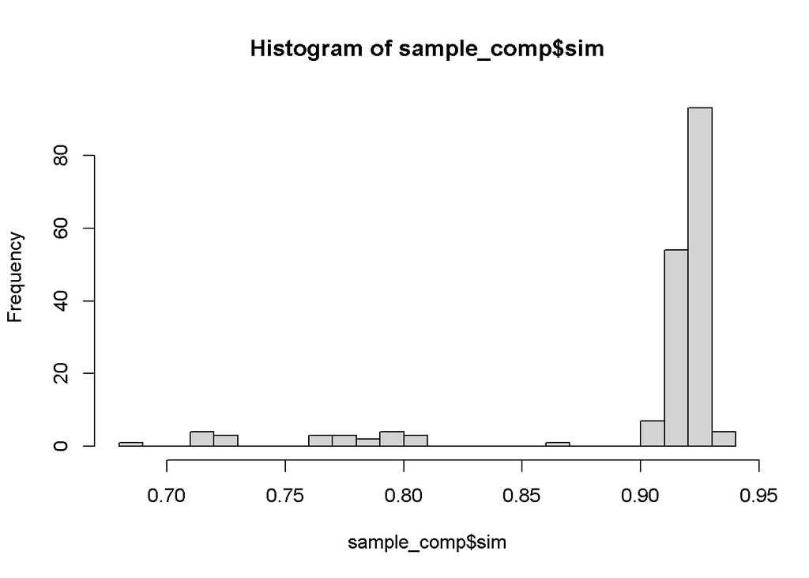

```r
hist(sample_comp$sim, breaks = 20)
```

Scores above 0.9 indicate a match. Surprisingly, scores between 0.65 and 0.9 may not be matches.

```r
sample_comp[!is.na(sample_comp$self_sim) & sample_comp$match == FALSE,]
```

```
##            gbrs_mouse giga_mouse       sim  self_sim match
## A-10354-19 A-10354-19 A-10322-19 0.7950348 0.6581679 FALSE
## A-10491-19 A-10491-19 A-10492-19 0.9200022 0.6603453 FALSE
## A-10492-19 A-10492-19 A-10512-19 0.7631965 0.6495073 FALSE
## A-10376-19 A-10376-19 A-10444-19 0.8080538 0.6638758 FALSE
## A-10356-19 A-10356-19 A-10308-19 0.7693736 0.7510688 FALSE
## A-10355-19 A-10355-19 A-10303-19 0.7944026 0.6517481 FALSE
```

```r
write.csv(sample_comp, file = file.path(results_dir, 'gbrs_giga_probs_mismatch.csv'),
          quote = FALSE, row.names = FALSE)
```

## Summary

Looking at the two tables of sample mismatches, there are some corrections that we can make.

A-10491-19 in GBRS matches with A-10492-19 in the Gigamuga data.

A-10487-19 in GBRS matches with A-10490-19 in the Gigamuga data.

Samples A-10132-19, A-10133-19, A-10134-19, A-10162-19, A-10257-19, A-10258-19, A-10259-19, A-10261-19, A-10263-19, A-10264-19, A-10286-19, A-10287-19, A-10290-19, A-10292-19, A-10493-19, A-10494-19 are in the GBRS data, but not the Gigamuga data.